Tomasz Dworowy  
29/12/2020

Next Word predictor. Simple application with generate three next word proposals for given phrase.

### Algorithm

Application use simple algorithm based on words frequencies.  
Steps:

1. Generate corpus and clear data.
2. Generate three, two and one grams from corpus.
3. Create data frame with three, two and one grams frequencies.
4. If new phrase match one of three or tow gram, return next word from that gram (start from most frequent)
5. If not rerun random word, weighted by frequency, from one gram

Algorithm requires lot of memory and it performance is not to good. Better solution will be use deep learning i even created kares prof of concept but could not deploy it to shinyapps.

### R implementation of algorithm:

```r
create_model <- function(text, max_words=3){
    print("Creating model")
    corpus <- generate_corpus(text, stop_words = stopwords("en"))
    one_grams <- word_freq(corpus, list(tokenize = uniTokenizer))
    n_grams <- word_freq(corpus, list(tokenize = modelTokenizer))


    model <- function(word){

      words_grep <- n_grams[grep((paste(word,"\\s", sep = "")), n_grams$ST),]
      count <- max_words
      words <- ""
      if(nrow(words_grep) >0){
        for(str in words_grep[1:max_words, "ST"]){
            next_word <-str_extract(str, paste('(?<=',word,'\\s)\\w+',sep = ""))
            words <- paste(words, next_word)
            count <- count -1
          }
      }
      if (count > 1){
             for (i in 1:count) {
               res <- sample_n(one_grams, 1, weight = one_grams$Freq)
               words <- paste(words, res$ST)
             }
           }

      return(words)
      }
    model
}
```

### Application page.

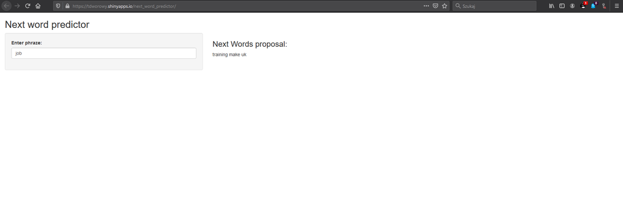

### Deep learning approach.

To create deep learning word predictor we can use Kares, popular deep learning python library with R interface available. Kares model could by composed with combination on three types of layers:

- Embedding (input layer) - transform words into dense vector representation.
- LSTM (few hide layers) - Long short-term memory, recurrent layer with will 'learn' patterns from text.
- Dense (output layer) - standard dense layer with the same amount of neurons as words in tokenizer. (might be preceded by few more dense layers.)

Kares example:

```
 model = Sequential()
    neurons = 500
    model.add(Embedding(vocabulary_size, seq_len, input_length=seq_len))
    model.add(LSTM(neurons, return_sequences=True))
    model.add(LSTM(neurons, recurrent_regularizer=l2(0.01), bias_regularizer=l2(0.01)))
    model.add(Dense(neurons, activation='relu', bias_regularizer=l2(0.01)))
    model.add(Dense(vocabulary_size, activation='softmax'))
```